# Hankowsky_HW6

Keith Hankowsky

2022-10-11

**General Comments [Gallagher’s comments in magenta]:** I just had to add the master problem file to your working directory, and your rmd knitted perfectly. Your solutions were tremendous earning a perfect score. I just had a couple of minor quibbles. I’ve analyzed the Cammen data about 200 times over the years, but I’ve never left the interaction term in. It is informative to leave it in, although it does screw up the nearly perfect allometric 3/4 power law. **Basic score (5+5)/10, Supplemental Score (2.5+2.5)/5 Master 5/5 Total score 20/10**

Hankowsky Homework Solutions

# Basic Problems

## 8.28

```r
#read in data
income <- Sleuth3::ex0828

#looking at the dataframe
head(income)
```

```
##   Subject   AFQT Educ Income2005
## 1       2  6.841   12       5500
## 2       6 99.393   16      65000
## 3       7 47.412   12      19000
## 4       8 44.022   14      36000
## 5       9 59.683   14      65000
## 6      13 72.313   16       8000
```

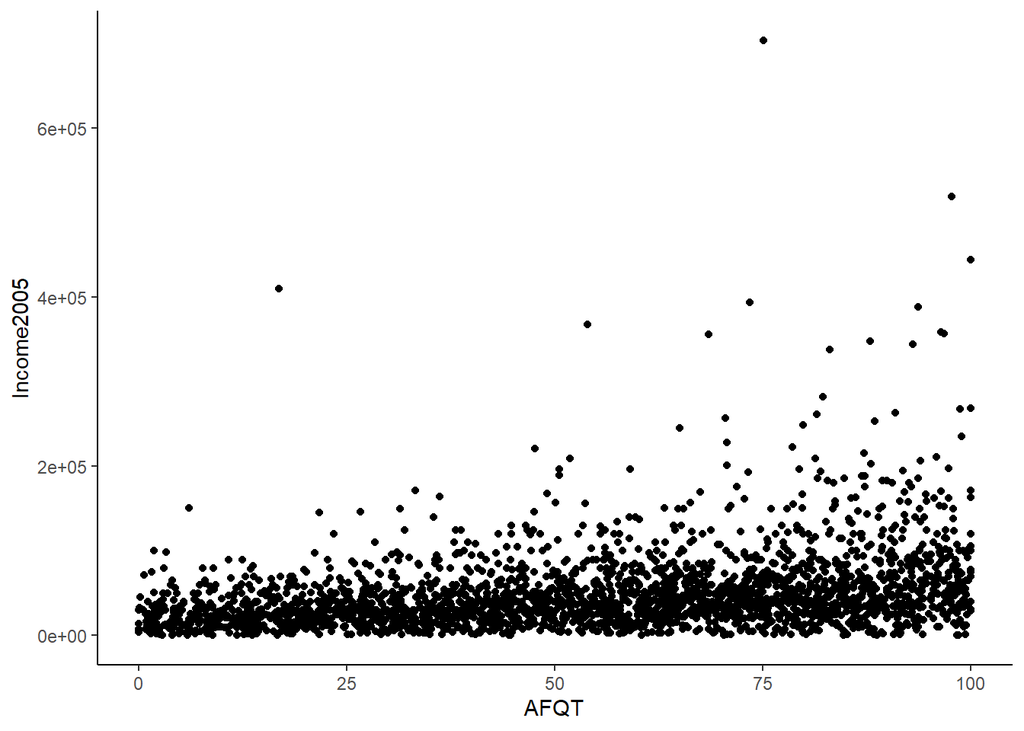

```r
#plot the 2005 income as a function of AFQT score
income %>%
  ggplot() +
  geom_jitter(aes(x = AFQT, y =  Income2005)) +
  theme_classic()
```

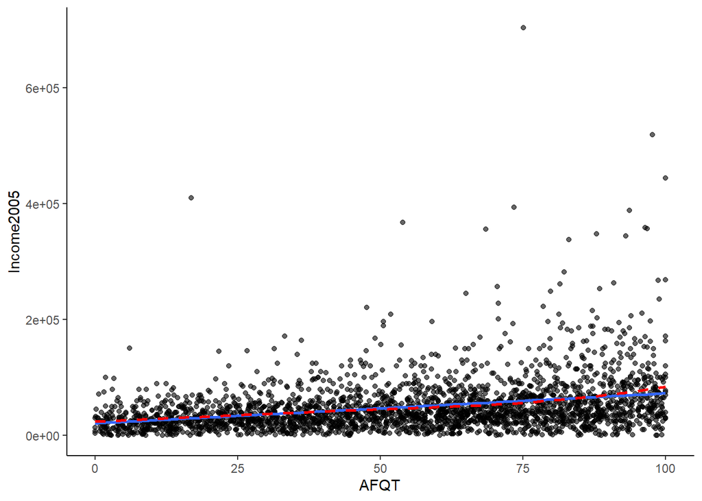

```r
#plot the 2005 income as a function of AFQT score with group means
# income %>%
#   ggplot(aes(x = AFQT, y =  Income2005)) +
#   geom_jitter(alpha = 0.4) +
#   stat_summary(fun = "mean", colour = "red", size = 2, geom = "point") +
#   stat_summary(fun = "mean", colour = "red", geom = "line") +
#   stat_summary(fun = mean,
#                geom = "errorbar",
#                fun.max = function(x) mean(x) + sd(x),
#                fun.min = function(x) mean(x) - sd(x), col = "red") +
#   theme_classic()

#plot it again with the regression line and smooth
income %>%
  ggplot(aes(x = AFQT, y =  Income2005)) +
  geom_jitter(alpha = 0.6) +
  geom_smooth(method = "lm", se = F) +
  geom_smooth(method = stats::loess, se = FALSE, col = "red", lty = 2) +
  theme_classic()
```

```r
#run the regression
income_lm <- lm(Income2005 ~ AFQT, data = income)
summary(income_lm)
```

```
##
## Call:
## lm(formula = Income2005 ~ AFQT, data = income)
##
## Residuals:
##    Min     1Q Median     3Q    Max
## -72004 -24075  -7815  12447 643506
##
## Coefficients:
##             Estimate Std. Error t value Pr(>|t|)
## (Intercept) 21181.66    1925.59   11.00   <2e-16 ***
## AFQT          518.68      31.51   16.46   <2e-16 ***
## ---
## Signif. codes:  0 '***' 0.001 '**' 0.01 '*' 0.05 '.' 0.1 ' ' 1
##
## Residual standard error: 44460 on 2582 degrees of freedom
## Multiple R-squared:  0.09496,    Adjusted R-squared:  0.09461
## F-statistic: 270.9 on 1 and 2582 DF,  p-value: < 2.2e-16
```

```r
anova(income_lm)
```

```
## Analysis of Variance Table
##
## Response: Income2005
##             Df     Sum Sq    Mean Sq F value    Pr(>F)
## AFQT         1 5.3556e+11 5.3556e+11  270.91 < 2.2e-16 ***
## Residuals 2582 5.1044e+12 1.9769e+09
## ---
## Signif. codes:  0 '***' 0.001 '**' 0.01 '*' 0.05 '.' 0.1 ' ' 1
```

```r
confint(income_lm)
```

```
##                  2.5 %     97.5 %
## (Intercept) 17405.7989 24957.5148
## AFQT          456.8886   580.4756
```

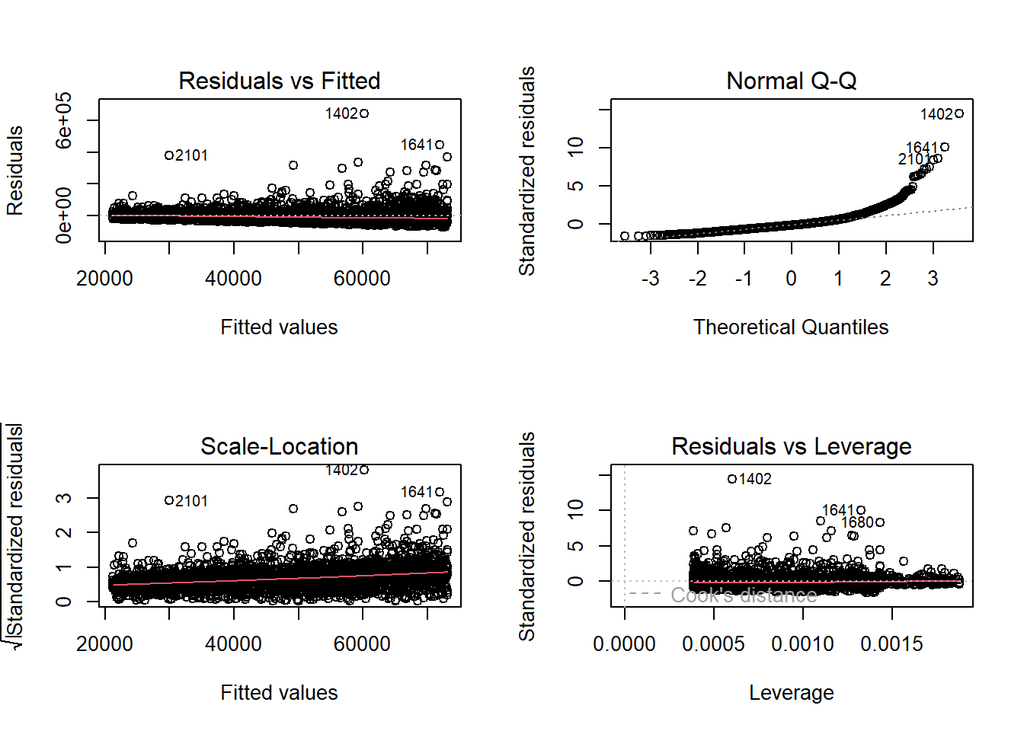

```r
#plot the diagnostics
par(mfrow=c(2,2))
plot(income_lm)
```

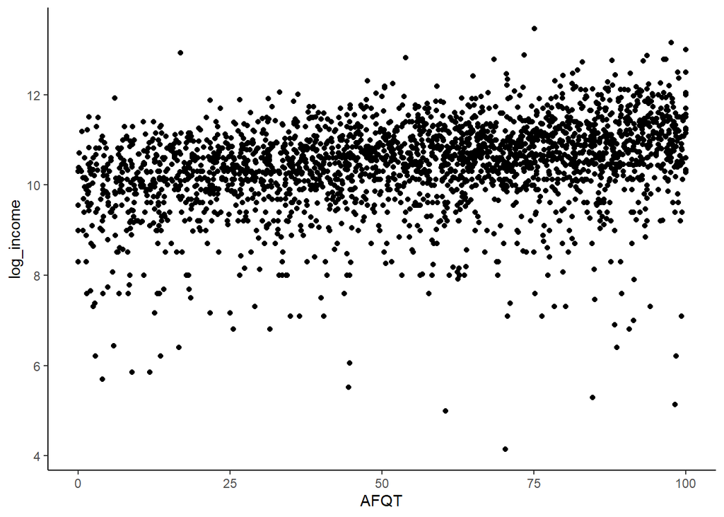

```r
###############################################################################

#log transform the data because of the trumpetting in the residual plot
income <- income %>%
  mutate(log_income = log(Income2005))

#plot the log(2005 income) as a function of AFQT score
income %>%
  ggplot() +
  geom_jitter(aes(x = AFQT, y =  log_income)) +
  theme_classic()
```

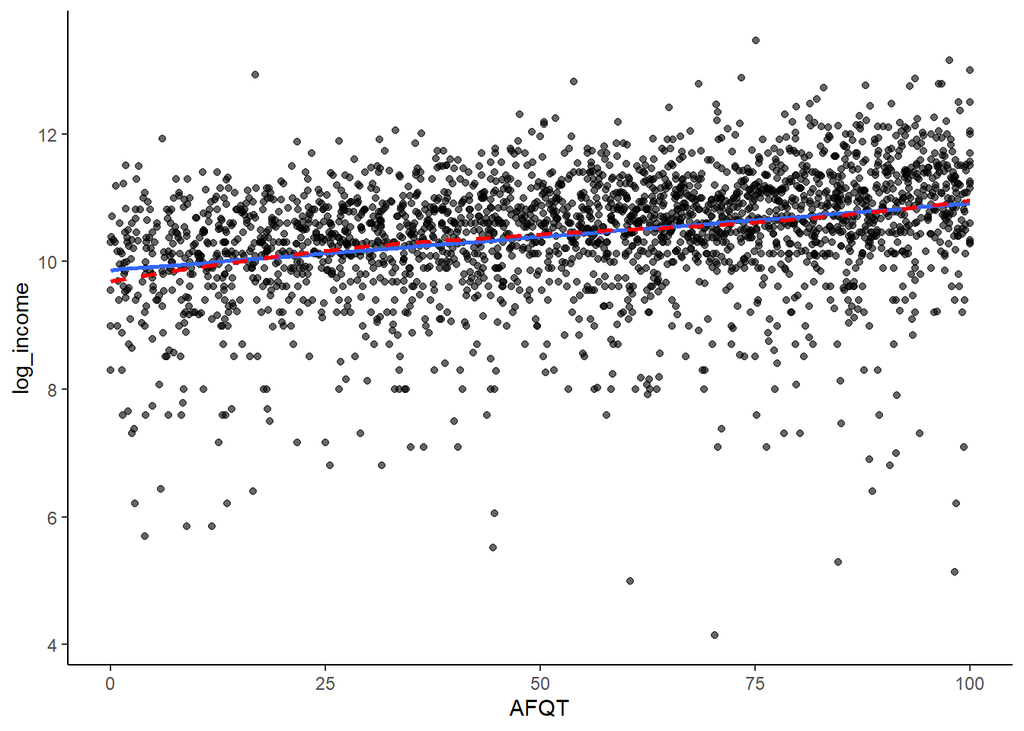

```r
#plot it again with the regression line and smooth
income %>%
  ggplot(aes(x = AFQT, y =  log_income)) +
  geom_jitter(alpha = 0.6) +
  geom_smooth(method = "lm", se = F) +
  geom_smooth(method = stats::loess, se = FALSE, col = "red", lty = 2) +
  theme_classic()
```

```r
#run the regression
income_lmb <- lm(log_income ~ AFQT, data = income)
summary(income_lmb)
```

```
##
## Call:
## lm(formula = log_income ~ AFQT, data = income)
##
## Residuals:
##     Min      1Q  Median      3Q     Max
## -6.4608 -0.3784  0.1224  0.5661  2.8794
##
## Coefficients:
##             Estimate Std. Error t value Pr(>|t|)
## (Intercept) 9.868419   0.040267  245.08   <2e-16 ***
## AFQT        0.010458   0.000659   15.87   <2e-16 ***
## ---
## Signif. codes:  0 '***' 0.001 '**' 0.01 '*' 0.05 '.' 0.1 ' ' 1
##
## Residual standard error: 0.9298 on 2582 degrees of freedom
## Multiple R-squared:  0.08887,    Adjusted R-squared:  0.08851
## F-statistic: 251.8 on 1 and 2582 DF,  p-value: < 2.2e-16
```

```r
anova(income_lmb)
```

```
## Analysis of Variance Table
##
## Response: log_income
##             Df  Sum Sq Mean Sq F value    Pr(>F)
## AFQT         1  217.71 217.706  251.84 < 2.2e-16 ***
## Residuals 2582 2232.07   0.864
## ---
## Signif. codes:  0 '***' 0.001 '**' 0.01 '*' 0.05 '.' 0.1 ' ' 1
```

```r
confint(income_lmb)
```

```
##                   2.5 %     97.5 %
## (Intercept) 9.789461406 9.94737749
## AFQT        0.009165405 0.01174977
```

```r
#back-transform the estimates
exp(income_lmb$coefficients)
```

```
##  (Intercept)         AFQT
## 19310.793100     1.010512
```

```r
exp(confint(income_lmb))
```

```
##                    2.5 %       97.5 %
## (Intercept) 17844.692528 20897.346904
## AFQT            1.009208     1.011819
```

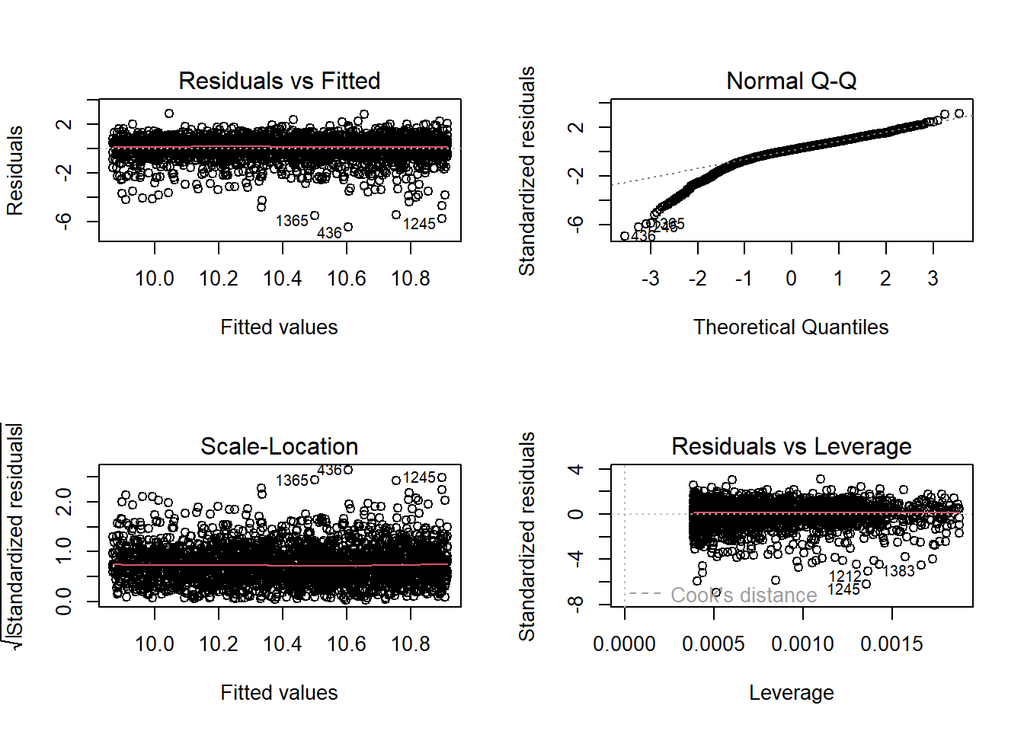

```r
#plot the diagnostics
par(mfrow=c(2,2))
plot(income_lmb)
```

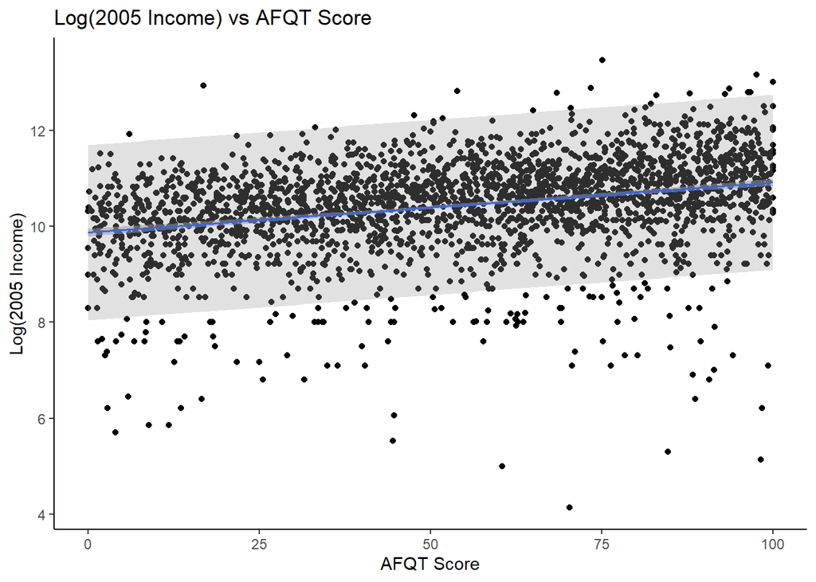

```r
#plot the presentation graphic
par(mfrow=c(1,1))
gf_jitter(log_income ~ AFQT, data = income) %>%
  gf_lm(interval = "prediction") %>%
  gf_lm(interval = "confidence", alpha = 0.5) +
  labs(title = "Log(2005 Income) vs AFQT Score",
       y = "Log(2005 Income)", x = "AFQT Score") +
  # geom_text(aes(7,600000, label = paste("R2 = ", signif(rsquared(income_lm), 3), "\n",
  #                                    "Intercept =",signif(income_lm$coef[[1]], 4), "\n",
  #                                    " Slope =",signif(income_lm$coef[[2]], 4)))) +
  theme_classic()
```

The residual diagnostic plot of the raw 2005 income as a function of AFQT score showed a pattern of trumpeting, so a log transformation was conducted. The diagnostics plots of the log-transformed income have no problematic trends, so the interpretation of the regression was performed with the log-transformed income data. These data provide overwhelming evidence that the 2005 income is associated with the IQ test score (AFQT score) ($\beta$ = 1.01, p-value < 0.0001). The IQ test score explained 9% of the variance in the 2005 income ($R^2$ = 0.088). The mean salary increases 1.01 times for each increase in AFQT scores (95% confidence intervals: 1.01 to 1.01).

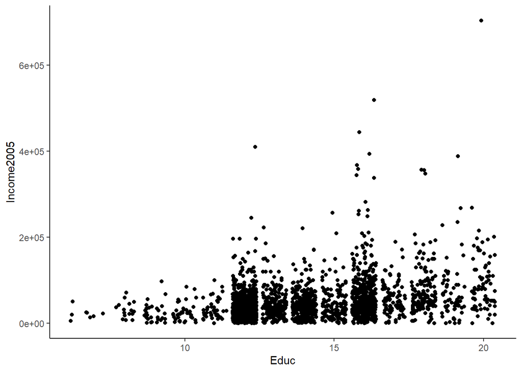

```r
#plot the 2005 income as a function of education
income %>%
  ggplot() +
  geom_jitter(aes(x = Educ, y =  Income2005)) +
  theme_classic()
```

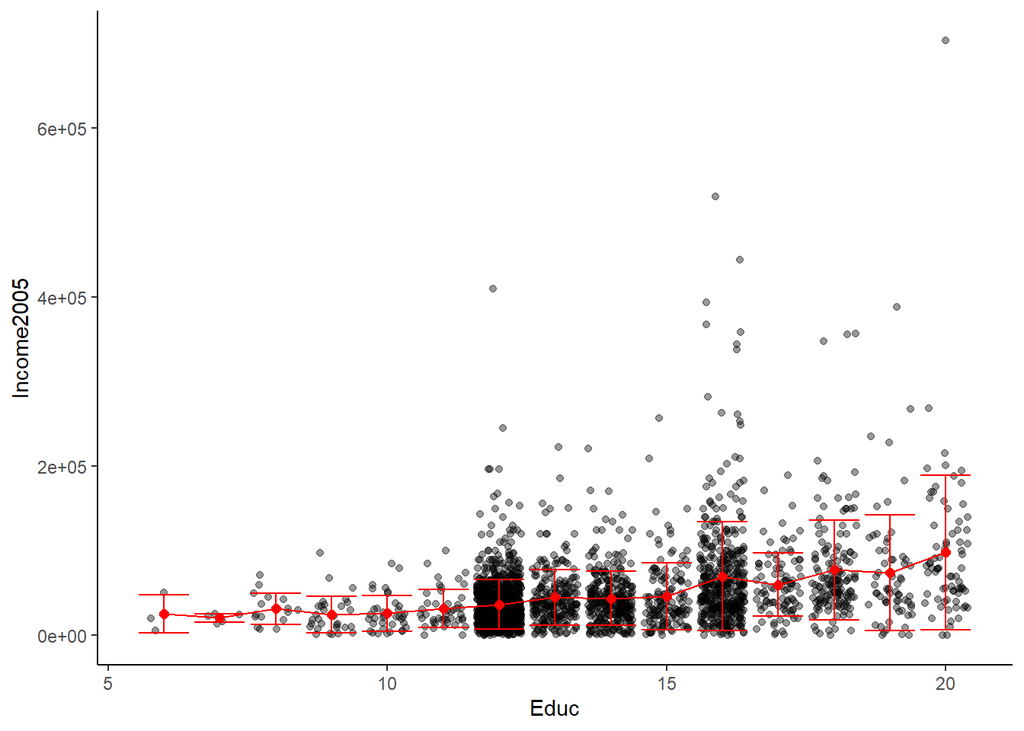

```r
#plot the 2005 income as a function of education with group means
income %>%
  ggplot(aes(x = Educ, y =  Income2005)) +
  geom_jitter(alpha = 0.4) +
  stat_summary(fun = "mean", colour = "red", size = 2, geom = "point") +
  stat_summary(fun = "mean", colour = "red", geom = "line") +
  stat_summary(fun = mean,
               geom = "errorbar",
               fun.max = function(x) mean(x) + sd(x),
               fun.min = function(x) mean(x) - sd(x), col = "red") +
  theme_classic()
```

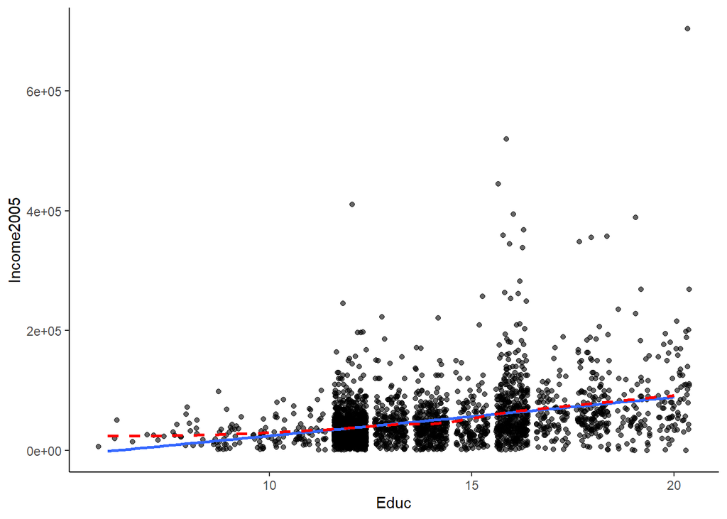

```r
#plot it again with the regression line and smooth
income %>%
  ggplot(aes(x = Educ, y =  Income2005)) +
  geom_jitter(alpha = 0.6) +
  geom_smooth(method = "lm", se = F) +
  geom_smooth(method = stats::loess, se = FALSE, col = "red", lty = 2) +
  theme_classic()
```

```r
#run the regression
income_lm2 <- lm(Income2005 ~ Educ, data = income)
summary(income_lm2)
```

```
##
## Call:
## lm(formula = Income2005 ~ Educ, data = income)
##
## Residuals:
##    Min     1Q Median     3Q    Max
## -88660 -24121  -7686  12782 614807
##
## Coefficients:
##             Estimate Std. Error t value Pr(>|t|)
## (Intercept) -40199.6     4865.0  -8.263 2.24e-16 ***
## Educ          6451.5      344.7  18.717  < 2e-16 ***
## ---
## Signif. codes:  0 '***' 0.001 '**' 0.01 '*' 0.05 '.' 0.1 ' ' 1
##
## Residual standard error: 43860 on 2582 degrees of freedom
## Multiple R-squared:  0.1195, Adjusted R-squared:  0.1191
## F-statistic: 350.3 on 1 and 2582 DF,  p-value: < 2.2e-16
```

```r
anova(income_lm2)
```

```
## Analysis of Variance Table
##
## Response: Income2005
##             Df     Sum Sq    Mean Sq F value    Pr(>F)
## Educ         1 6.7382e+11 6.7382e+11  350.33 < 2.2e-16 ***
## Residuals 2582 4.9662e+12 1.9234e+09
## ---
## Signif. codes:  0 '***' 0.001 '**' 0.01 '*' 0.05 '.' 0.1 ' ' 1
```

```r
confint(income_lm2)
```

```
##                  2.5 %     97.5 %
## (Intercept) -49739.365 -30659.786
## Educ          5775.593   7127.356
```

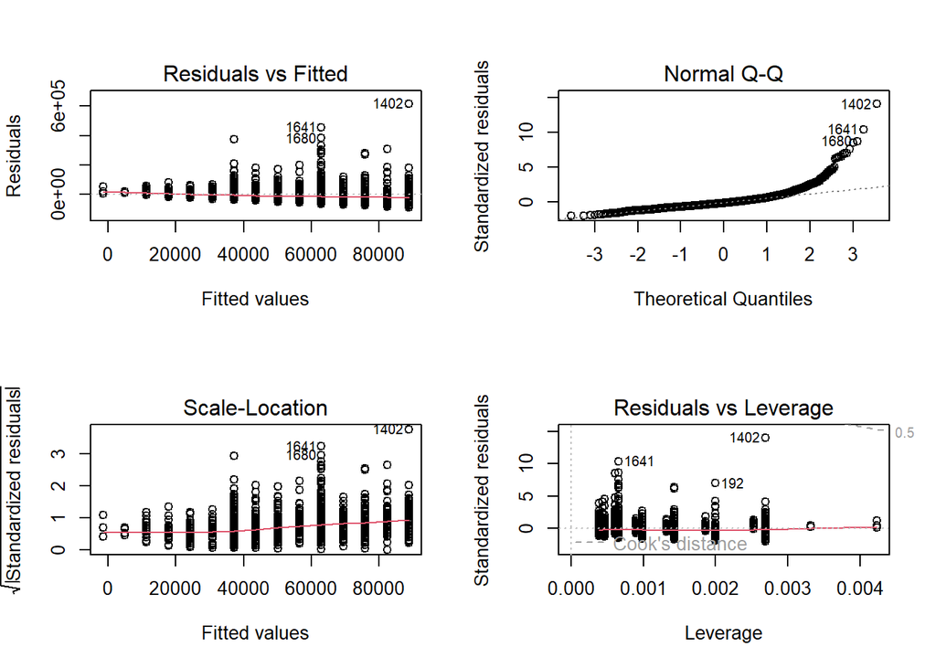

```r
#plot the diagnostics
par(mfrow=c(2,2))
plot(income_lm2)
```

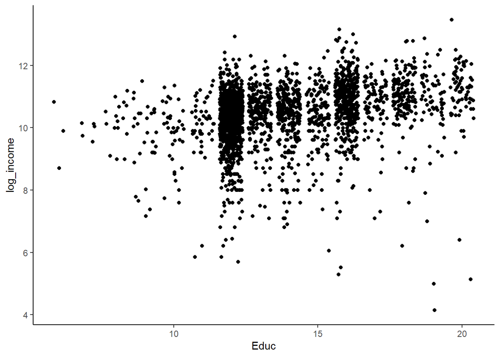

```r
###############################################################################

#plot the log(2005 income) as a function of education
income %>%
  ggplot() +
  geom_jitter(aes(x = Educ, y =  log_income)) +
  theme_classic()
```

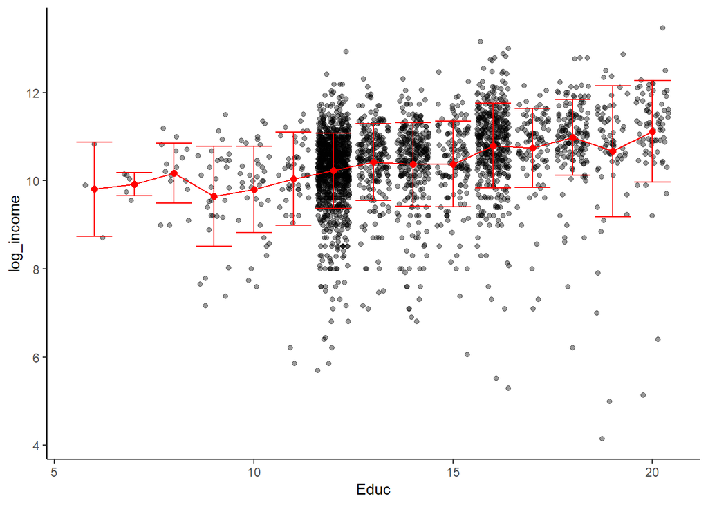

```r
#plot the log(2005 income) as a function of education with group means
income %>%
  ggplot(aes(x = Educ, y =  log_income)) +
  geom_jitter(alpha = 0.4) +
  stat_summary(fun = "mean", colour = "red", size = 2, geom = "point") +
  stat_summary(fun = "mean", colour = "red", geom = "line") +
  stat_summary(fun = mean,
               geom = "errorbar",
               fun.max = function(x) mean(x) + sd(x),
               fun.min = function(x) mean(x) - sd(x), col = "red") +
  theme_classic()
```

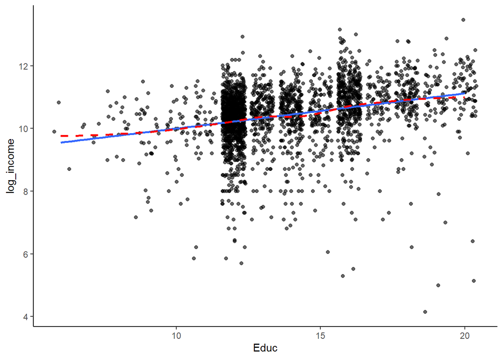

```r
#plot it again with the regression line and smooth
income %>%
  ggplot(aes(x = Educ, y =  log_income)) +
  geom_jitter(alpha = 0.6) +
  geom_smooth(method = "lm", se = F) +
  geom_smooth(method = stats::loess, se = FALSE, col = "red", lty = 2) +
  theme_classic()
```